# **The Effect of Song Length on Song Popularity Throughout Time**

**Addie Ben-Yoseph and Ben Frankstein**

**Project URL:** https://benfrankstein.github.io/

🔗 [Link to our GitHub Pages site](https://benfrankstein.github.io/)

CMPS 3160 – Introduction to Data Science, Final Tutorial

# 1. Introduction & Motivation

If you have spent any time listening to music, you might have felt that popular songs feel "shorter" today. This isn't always how its been. Throughout the album era of the 70s and 80s, popular songs grew noticably longer, continuing to grow in length through those decades.

However, after the introduction of streaming services like Spotify and Apple Music, the music industry went through a fundamental change in terms of how people produce music. In order to be successful through these platforms, gaining streams and listeners is essential. However, a single stream is only counted after a song is listened to for 30 seconds. For artists, this has led to much less incententive around going through the struggle of creating longer songs, as "success" can now just be measured by breaking that 30 second mark for stream revenue.

Based off of this, our tutorial asks two related questions:

> **1. Has song duration actually changed over time, and if so, when did the shift happen?**

> **2. Does song duration meaningfully predict how successful a song is on the charts, and has that relationship changed between the album era and the streaming era?**

Our first question asks how the song duration has changed over the decades, and if there is a correlation between the popularity of the song and its length, or if it is an external economic-incentive pressure that causes the duration change.

Our second question asks if the data that we have based on popularity, genre, artist, duration, and more can help us predict how successful a song will be in the future before its released.

# 2. Research Question & Hypotheses

**Research Question:** How does the duration of a song relate to its popularity, and how has that relationship changed over time?

Based on this research question, we will test two hypotheses:

> **Descriptive Hypothesis:** The trend in song duration over time is *piecewise*, changing drastically in trend before the 2000s and after. More specifically, song durations were increasing from 1958 to the end of the 1990s, but began to decrease after 2000, making these two slopes statistically different.

> **Inferential Hypothesis:** After the 2000s, shorter songs began charting higher, while prior to the 2000s, this seemed to be the opposite. So, we expect to find that song length has an effect on chart success depending on the era, with shorter songs charting better in the streaming era of the 2000-2020s.

## Collaboration plan

We met on Zoom/in-person 1-2 times a week in order to complete this project. In addition, we set up a page on Github where we can work on code and troubleshoot as well as using a shared doc where we can keep track of any ideas and additional information we planned to share in the final tutorial.

# 3. Data Sources

We are combining two datasets in order to properly answer our research question.

## Dataset 1 — 30,000 Spotify Songs

- **Source:** [Kaggle — 30,000 Spotify Songs](https://www.kaggle.com/datasets/joebeachcapital/30000-spotify-songs)
- **Size:** ~32,800 rows × 23 columns in raw form
- **What's in it:** track metadata and audio features pulled from the [Spotify Web API](https://developer.spotify.com/documentation/web-api), including duration, release date, genre, danceability, energy, tempo, valence, and a `track_popularity` score (0–100).
- **Why we need it:** We need the duration and release date in order to track the songs properly.
- **Why it's not enough on its own:** the `track_popularity` field is computed with a favoring towards the recent 30 day stream count. This means that songs that were popular in the 70s/80s will have a low track popularity score even though it was a popular song during its time.

## Dataset 2 — Billboard Hot 100 (1958–present)

- **Source:** [`utdata/rwd-billboard-data`](https://github.com/utdata/rwd-billboard-data) on GitHub
- **Size:** ~340,000 rows × 7 columns (one row per song-week)
- **What's in it:** weekly chart positions for every song that has ever charted on Billboard's Hot 100 since August 1958.
- **How it's collected:** Billboard editorially compiles the chart from a weighted combination of US radio airplay, sales, and (since 2007) streams.
- **Why we need it:** the Hot 100 reflects how popular a song *was at the time*. A 1965 #1 stays a 1965 #1 forever. This gives us an era-fair popularity measure that Spotify can't.

## Reproducibility note

The Spotify CSV must be downloaded from Kaggle and placed at `/content/drive/My Drive/spotify_songs.csv` (or you can change the path in cell 4 to wherever you put it). The Billboard CSV is downloaded automatically from the GitHub archive in cell 9.

# 4. Data Loading & Preprocessing (ETL)

We follow the **tidy data principles** where each variable is a column, each observation is a row, each value is a cell.

## 4.1 — Spotify

```python
import pandas as pd
import matplotlib.pyplot as plt
import seaborn as sns

from google.colab import drive
drive.mount('/content/drive')
spotify = pd.read_csv('/content/drive/My Drive/spotify_songs.csv')

#spotify = pd.read_csv('/content/spotify_songs.csv')

# preview shape of data and columns
print("Spotify Shape:", spotify.shape)
spotify.head()
```

```
Spotify Shape: (32833, 23)
```

|  | track_id | track_name | track_artist | track_popularity | track_album_id | track_album_name | track_album_release_date | playlist_name | playlist_id | playlist_genre | ... | key | loudness | mode | speechiness | acousticness | instrumentalness | liveness | valence | tempo | duration_ms |
| --- | --- | --- | --- | --- | --- | --- | --- | --- | --- | --- | --- | --- | --- | --- | --- | --- | --- | --- | --- | --- | --- |
| 0 | 6f807x0ima9a1j3VPbc7VN | I Don't Care (with Justin Bieber) - Loud Luxur... | Ed Sheeran | 66 | 2oCs0DGTsRO98Gh5ZSl2Cx | I Don't Care (with Justin Bieber) [Loud Luxury... | 2019-06-14 | Pop Remix | 37i9dQZF1DXcZDD7cfEKhW | pop | ... | 6 | -2.634 | 1 | 0.0583 | 0.1020 | 0.000000 | 0.0653 | 0.518 | 122.036 | 194754 |
| 1 | 0r7CVbZTWZgbTCYdfa2P31 | Memories - Dillon Francis Remix | Maroon 5 | 67 | 63rPSO264uRjW1X5E6cWv6 | Memories (Dillon Francis Remix) | 2019-12-13 | Pop Remix | 37i9dQZF1DXcZDD7cfEKhW | pop | ... | 11 | -4.969 | 1 | 0.0373 | 0.0724 | 0.004210 | 0.3570 | 0.693 | 99.972 | 162600 |
| 2 | 1z1Hg7Vb0AhHDiEmnDE79l | All the Time - Don Diablo Remix | Zara Larsson | 70 | 1HoSmj2eLcsrR0vE9gThr4 | All the Time (Don Diablo Remix) | 2019-07-05 | Pop Remix | 37i9dQZF1DXcZDD7cfEKhW | pop | ... | 1 | -3.432 | 0 | 0.0742 | 0.0794 | 0.000023 | 0.1100 | 0.613 | 124.008 | 176616 |
| 3 | 75FpbthrwQmzHlBJLuGdC7 | Call You Mine - Keanu Silva Remix | The Chainsmokers | 60 | 1nqYsOef1yKKuGOVchbsk6 | Call You Mine - The Remixes | 2019-07-19 | Pop Remix | 37i9dQZF1DXcZDD7cfEKhW | pop | ... | 7 | -3.778 | 1 | 0.1020 | 0.0287 | 0.000009 | 0.2040 | 0.277 | 121.956 | 169093 |
| 4 | 1e8PAfcKUYoKkxPhrHqw4x | Someone You Loved - Future Humans Remix | Lewis Capaldi | 69 | 7m7vv9wlQ4i0LFuJiE2zsQ | Someone You Loved (Future Humans Remix) | 2019-03-05 | Pop Remix | 37i9dQZF1DXcZDD7cfEKhW | pop | ... | 1 | -4.672 | 1 | 0.0359 | 0.0803 | 0.000000 | 0.0833 | 0.725 | 123.976 | 189052 |

5 rows × 23 columns

```python
#inspect the data shape, types and missing values
print("Raw Spotify shape:", spotify.shape)
print("\nDtypes:")
print(spotify.dtypes)
print("\nMissing values per column:")
print(spotify.isnull().sum().sort_values(ascending=False))
```

```
Raw Spotify shape: (32833, 23)

Dtypes:
track_id                     object
track_name                   object
track_artist                 object
track_popularity              int64
track_album_id               object
track_album_name             object
track_album_release_date     object
playlist_name                object
playlist_id                  object
playlist_genre               object
playlist_subgenre            object
danceability                float64
energy                      float64
key                           int64
loudness                    float64
mode                          int64
speechiness                 float64
acousticness                float64
instrumentalness            float64
liveness                    float64
valence                     float64
tempo                       float64
duration_ms                   int64
dtype: object

Missing values per column:
track_name                  5
track_artist                5
track_album_name            5
track_id                    0
track_popularity            0
track_album_id              0
track_album_release_date    0
playlist_name               0
playlist_id                 0
playlist_genre              0
playlist_subgenre           0
danceability                0
energy                      0
key                         0
loudness                    0
mode                        0
speechiness                 0
acousticness                0
instrumentalness            0
liveness                    0
valence                     0
tempo                       0
duration_ms                 0
dtype: int64
```

```python
# keep the columns that matter for our analysis
spotify = spotify[['track_name', 'track_artist', 'track_popularity',
                    'track_album_release_date', 'playlist_genre', 'duration_ms']]
spotify['duration_sec'] = spotify['duration_ms'] / 1000 #make the time human readable in seconds

#transform date to datetime and extract the year
spotify['track_album_release_date'] = pd.to_datetime(spotify['track_album_release_date'], errors='coerce')
spotify['release_year'] = spotify['track_album_release_date'].dt.year

#drop the columns that we transformed into more readable
spotify = spotify.drop(columns=['duration_ms', 'track_album_release_date'])

#dropping rows where the release year or track name/artist is missing
spotify = spotify.dropna(subset=['release_year', 'track_name', 'track_artist'])
spotify = spotify.drop_duplicates() #drop duplicate rows with all the columns being exactly the same

#make the year an integer
spotify['release_year'] = spotify['release_year'].astype(int)

#look at the shape, types and missing values to make sure we cleaned up the data properly
print("Tidied Spotify shape:", spotify.shape)
print("\nDtypes:")
print(spotify.dtypes)
print("\nMissing values per column:")
print(spotify.isnull().sum().sort_values(ascending=False))
```

```
Tidied Spotify shape: (28622, 6)

Dtypes:
track_name           object
track_artist         object
track_popularity      int64
playlist_genre       object
duration_sec        float64
release_year          int64
dtype: object

Missing values per column:
track_name          0
track_artist        0
track_popularity    0
playlist_genre      0
duration_sec        0
release_year        0
dtype: int64
```

```python
spotify.head()
```

|  | track_name | track_artist | track_popularity | playlist_genre | duration_sec | release_year |
| --- | --- | --- | --- | --- | --- | --- |
| 0 | I Don't Care (with Justin Bieber) - Loud Luxur... | Ed Sheeran | 66 | pop | 194.754 | 2019 |
| 1 | Memories - Dillon Francis Remix | Maroon 5 | 67 | pop | 162.600 | 2019 |
| 2 | All the Time - Don Diablo Remix | Zara Larsson | 70 | pop | 176.616 | 2019 |
| 3 | Call You Mine - Keanu Silva Remix | The Chainsmokers | 60 | pop | 169.093 | 2019 |
| 4 | Someone You Loved - Future Humans Remix | Lewis Capaldi | 69 | pop | 189.052 | 2019 |

## 4.2 — Billboard

```python
# Download the Billboard Hot 100 archive from the utdata GitHub repo.

import urllib.request
import os

BILLBOARD_URL = (
    "https://raw.githubusercontent.com/utdata/rwd-billboard-data/"
    "main/data-out/hot-100-current.csv"
)
BILLBOARD_PATH = "hot100.csv"

# Only download if we don't already have it cached locally
if not os.path.exists(BILLBOARD_PATH):
    urllib.request.urlretrieve(BILLBOARD_URL, BILLBOARD_PATH)
    print(f"Downloaded to {BILLBOARD_PATH}")
else:
    print(f"Using cached copy at {BILLBOARD_PATH}")

print(f"File size: {os.path.getsize(BILLBOARD_PATH) / 1e6:.1f} MB")
```

```
Using cached copy at hot100.csv
File size: 19.5 MB
```

```python
# Load the raw Billboard CSV into billboard_raw variable and look at the columns and datatypes
import pandas as pd

billboard_raw = pd.read_csv(BILLBOARD_PATH)

print("Raw Billboard shape:", billboard_raw.shape)
print("\nColumns:", list(billboard_raw.columns))
print("\nDtypes:")
print(billboard_raw.dtypes)
print("\nMissing values per column:")
print(billboard_raw.isnull().sum().sort_values(ascending=False))
billboard_raw.head()
```

```
Raw Billboard shape: (353600, 7)

Columns: ['chart_week', 'current_week', 'title', 'performer', 'last_week', 'peak_pos', 'wks_on_chart']

Dtypes:
chart_week       object
current_week      int64
title            object
performer        object
last_week       float64
peak_pos          int64
wks_on_chart      int64
dtype: object

Missing values per column:
last_week       32460
current_week        0
chart_week          0
title               0
performer           0
peak_pos            0
wks_on_chart        0
dtype: int64
```

|  | chart_week | current_week | title | performer | last_week | peak_pos | wks_on_chart |
| --- | --- | --- | --- | --- | --- | --- | --- |
| 0 | 2022-01-01 | 1 | All I Want For Christmas Is You | Mariah Carey | 1.0 | 1 | 50 |
| 1 | 2022-01-01 | 2 | Rockin' Around The Christmas Tree | Brenda Lee | 2.0 | 2 | 44 |
| 2 | 2022-01-01 | 3 | Jingle Bell Rock | Bobby Helms | 4.0 | 3 | 41 |
| 3 | 2022-01-01 | 4 | A Holly Jolly Christmas | Burl Ives | 5.0 | 4 | 25 |
| 4 | 2022-01-01 | 5 | Easy On Me | Adele | 3.0 | 1 | 11 |

### Tidy transformations

Before we can join to Spotify we need to:

1. **Keep columns we want to use**
2. **Parse `chart_week` as a datetime** and extract the year.
3. **Drop rows that have missing songs or performers**
4. **Aggregate to one row per song** — collapse the weekly rows down to a single row per `(song, performer)` with:
   - `peak_position` — the best (lowest-numbered) position the song ever hit. This is our primary ground-truth popularity signal.
   - `weeks_on_chart` — how many distinct weeks it appeared. A secondary popularity signal capturing longevity.
   - `year_first_charted` — the year the song debuted on the Hot 100. This is what we'll treat as its "release era" for historical comparisons.

```python
# Normalize our column names
rename_map = {
    "title":    "song",
    "peak_pos": "peak_position",
    "chart_date":     "chart_week",
    "chart_position": "current_week",
    "time_on_chart":  "wks_on_chart",
}
billboard_raw = billboard_raw.rename(columns=rename_map)
print("Standardized columns:", billboard_raw.columns.tolist())

# columns that we will use for our second database
needed = ["chart_week", "song", "performer", "current_week",
          "peak_position", "wks_on_chart"]
missing = [c for c in needed if c not in billboard_raw.columns]
if missing:
    raise KeyError(f"Expected Billboard columns missing: {missing}. "
                   f"Got: {billboard_raw.columns.tolist()}")

billboard = billboard_raw[needed].copy()

# prase chart week to be datetime so we can extract the year
billboard["chart_week"] = pd.to_datetime(billboard["chart_week"], errors="coerce")

# drop rows where songs and performers are
before = len(billboard)
billboard = billboard.dropna(subset=["song", "performer", "chart_week"])

# print data to see the new shapes, types and names all together
print("\nCleaned weekly Billboard shape:", billboard.shape)
print("\nDate range:", billboard["chart_week"].min().date(),
      "to", billboard["chart_week"].max().date())
print("\nDtypes:")
print(billboard.dtypes)
billboard.head()
```

```
Standardized columns: ['chart_week', 'current_week', 'song', 'performer', 'last_week', 'peak_position', 'wks_on_chart']

Cleaned weekly Billboard shape: (353600, 6)

Date range: 1958-08-04 to 2026-05-09

Dtypes:
chart_week       datetime64[ns]
song                     object
performer                object
current_week              int64
peak_position             int64
wks_on_chart              int64
dtype: object
```

|  | chart_week | song | performer | current_week | peak_position | wks_on_chart |
| --- | --- | --- | --- | --- | --- | --- |
| 0 | 2022-01-01 | All I Want For Christmas Is You | Mariah Carey | 1 | 1 | 50 |
| 1 | 2022-01-01 | Rockin' Around The Christmas Tree | Brenda Lee | 2 | 2 | 44 |
| 2 | 2022-01-01 | Jingle Bell Rock | Bobby Helms | 3 | 3 | 41 |
| 3 | 2022-01-01 | A Holly Jolly Christmas | Burl Ives | 4 | 4 | 25 |
| 4 | 2022-01-01 | Easy On Me | Adele | 5 | 1 | 11 |

```python
# collpase the weekly rows into groups if the same song has been present on the charts for more than 1 week to reduce data bloat
billboard_songs = (
    billboard
    .groupby(["song", "performer"], as_index=False)
    .agg(
        peak_position=("peak_position", "min"),
        weeks_on_chart=("chart_week", "nunique"),
        year_first_charted=("chart_week", lambda s: s.min().year),
    )
)

# make sure datatypes are properly casted to use for analysis later
billboard_songs["peak_position"] = billboard_songs["peak_position"].astype(int)
billboard_songs["weeks_on_chart"] = billboard_songs["weeks_on_chart"].astype(int)
billboard_songs["year_first_charted"] = billboard_songs["year_first_charted"].astype(int)

print("One-row-per-song Billboard shape:", billboard_songs.shape)
print("\nDtypes:")
print(billboard_songs.dtypes)
print("\nMissing values per column:")
print(billboard_songs.isnull().sum().sort_values(ascending=False))
billboard_songs.head()
```

```
One-row-per-song Billboard shape: (32553, 5)

Dtypes:
song                  object
performer             object
peak_position          int64
weeks_on_chart         int64
year_first_charted     int64
dtype: object

Missing values per column:
song                  0
performer             0
peak_position         0
weeks_on_chart        0
year_first_charted    0
dtype: int64
```

|  | song | performer | peak_position | weeks_on_chart | year_first_charted |
| --- | --- | --- | --- | --- | --- |
| 0 | "B" Girls | Young And Restless | 54 | 15 | 1990 |
| 1 | "Cherry Cherry" from Hot August Night | Neil Diamond | 31 | 10 | 1973 |
| 2 | "Having A Party" Medley | The Ovations (Featuring Louis Williams) | 56 | 9 | 1973 |
| 3 | "Joy" Pt. I | Isaac Hayes | 30 | 9 | 1973 |
| 4 | "Roots" Medley | Quincy Jones | 57 | 7 | 1977 |

## Merging Spotify and Billboard

Now we join the two cleaned datasets on `(artist, track)`. For example, the same song can appear as `"Umbrella"` in one source and `"Umbrella (feat. JAY-Z)"` in the other. Because of this, a direct string join on raw names will miss most matches.

To handle this we build a **normalized join key** on both sides, which will:

- lowercase everything
- strip featured-artist tags like `(feat. X)`, `- Remix`, `- Remastered`
- remove punctuation and collapse whitespace
- for the artist field, keep only the primary/first artist

This won't catch every match (misspellings, translated titles, etc.) but it gets us a solid intersection. We use an **inner join** so the merged dataset contains only songs that appear in *both* sources. These are the songs for which we have both audio/duration features AND historical chart performance.

```python
import re

#normalize the titles so its easier to do comparisons
def normalize_title(s: str) -> str:
    s = str(s).lower()
    # remove parenthesized or bracketed additions: (these are common in song titles)
    s = re.sub(r"[\(\[].*?[\)\]]", "", s)
    # strip " - Remix", " - Remastered 2011", " - Radio Edit", etc.
    s = re.sub(r"\s*-\s*(remix|remaster(ed)?|radio edit|single version|album version|live|acoustic|mono|stereo).*$", "", s)
    # remove punctuation
    s = re.sub(r"[^\w\s]", "", s)
    # collapse whitespace
    s = re.sub(r"\s+", " ", s).strip()
    return s
#normalize the title to keep only the main artist and not all the featuring artists
def normalize_artist(s: str) -> str:
    s = str(s).lower()
    # cut at "featuring", "feat.", "ft.", "with", "x", "&", ","
    s = re.split(r"\s+(?:featuring|feat\.?|ft\.?|with|x|&|,)\s+", s)[0]
    s = re.sub(r"[^\w\s]", "", s)
    s = re.sub(r"\s+", " ", s).strip()
    return s

# identify the join keys on spotify dataset
spotify["_track_key"]  = spotify["track_name"].apply(normalize_title)
spotify["_artist_key"] = spotify["track_artist"].apply(normalize_artist)

#identify the join keys on the billboard dataset
billboard_songs["_track_key"]  = billboard_songs["song"].apply(normalize_title)
billboard_songs["_artist_key"] = billboard_songs["performer"].apply(normalize_artist)

# Inner join — keep only songs found in both datasets.
merged = spotify.merge(
    billboard_songs,
    on=["_track_key", "_artist_key"],
    how="inner",
)

# if a song has duplicates keep the row with the highest spotify popularity. this is to reduce the duplicate comparisons that we will make
# we made the assumption that other duplicates are remixes or covers which aren't as popular as the orignal most of the time
merged = (
    merged
    .sort_values("track_popularity", ascending=False)
    .drop_duplicates(subset=["_track_key", "_artist_key"], keep="first")
    .reset_index(drop=True)
)

# Drop the join-key columns
merged = merged.drop(columns=["_track_key", "_artist_key"])

print("Spotify rows:            ", len(spotify))
print("Billboard songs rows:    ", len(billboard_songs))
print("Merged (inner-join) rows:", len(merged))
print("\nDtypes:")
print(merged.dtypes)
print("\nMissing values per column:")
print(merged.isnull().sum())
merged.head()
```

```
Spotify rows:             28622
Billboard songs rows:     32553
Merged (inner-join) rows: 3147

Dtypes:
track_name             object
track_artist           object
track_popularity        int64
playlist_genre         object
duration_sec          float64
release_year            int64
song                   object
performer              object
peak_position           int64
weeks_on_chart          int64
year_first_charted      int64
dtype: object

Missing values per column:
track_name            0
track_artist          0
track_popularity      0
playlist_genre        0
duration_sec          0
release_year          0
song                  0
performer             0
peak_position         0
weeks_on_chart        0
year_first_charted    0
dtype: int64
```

|  | track_name | track_artist | track_popularity | playlist_genre | duration_sec | release_year | song | performer | peak_position | weeks_on_chart | year_first_charted |
| --- | --- | --- | --- | --- | --- | --- | --- | --- | --- | --- | --- |
| 0 | Dance Monkey | Tones and I | 100 | pop | 209.438 | 2019 | Dance Monkey | Tones And I | 4 | 36 | 2019 |
| 1 | ROXANNE | Arizona Zervas | 99 | edm | 163.636 | 2019 | Roxanne | Arizona Zervas | 4 | 26 | 2019 |
| 2 | Tusa | KAROL G | 98 | pop | 200.960 | 2019 | Tusa | Karol G & Nicki Minaj | 42 | 21 | 2019 |
| 3 | The Box | Roddy Ricch | 98 | edm | 196.653 | 2019 | The Box | Roddy Ricch | 1 | 38 | 2019 |
| 4 | Circles | Post Malone | 98 | r&b | 215.280 | 2019 | Circles | Post Malone | 1 | 61 | 2019 |

### Tidy data check — merged dataset

Our merged DataFrame satisfies three tidy-data rules:

- **Each variable is its own column** — `track_name`, `track_artist`, `track_popularity`, `playlist_genre`, `duration_sec`, `release_year`, `peak_position`, `weeks_on_chart`, `year_first_charted` are each one variable.
- **Each observation is its own row** — one row = one song that appears in both Spotify and Billboard.
- **Each cell is a single value** — no lists, no embedded multi-values.

Dtypes are set appropriately (numeric where numeric, string where string, int for years and chart positions). No missing values remain in the columns we'll use for modeling.

This merged dataset is what the EDA and modeling sections below will work from. We kept the two source datasets (`spotify` and `billboard_songs`) around separately too, in case we want to do any analysis that requires the full non-intersected populations.

# 5. Exploratory Data Analysis

We do EDA in two parts. **Part 1 (5.1)** uses only the Spotify catalog and Spotify's own popularity score. **Part 2 (5.2)** brings in Billboard peak position. The two parts disagree, and that disagreement is the most important finding in the whole tutorial.

## 5.1 — Spotify-only view: variable distributions and summary statistics

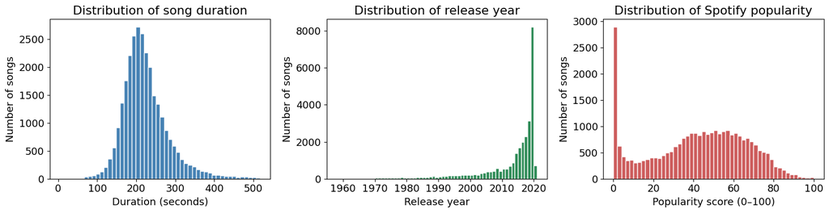

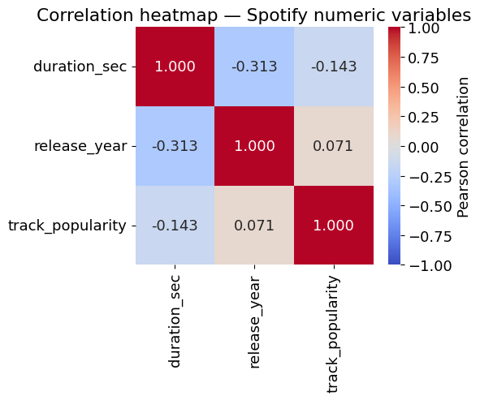

```python
# create 3 plots that show distributions
fig, axes = plt.subplots(1, 3, figsize=(15, 4))

# histogram of song duration
axes[0].hist(spotify['duration_sec'], bins=50, color='steelblue',
             edgecolor='white')
# set labels and title
axes[0].set_title('Distribution of song duration')
axes[0].set_xlabel('Duration (seconds)')
axes[0].set_ylabel('Number of songs')

# histogram of release year
axes[1].hist(spotify['release_year'], bins=range(1958, 2022),
             color='seagreen', edgecolor='white')
# set labels and title
axes[1].set_title('Distribution of release year')
axes[1].set_xlabel('Release year')
axes[1].set_ylabel('Number of songs')

# histogram of spotify popularity score
axes[2].hist(spotify['track_popularity'], bins=50, color='indianred',
             edgecolor='white')
# set labels and title
axes[2].set_title('Distribution of Spotify popularity')
axes[2].set_xlabel('Popularity score (0–100)')
axes[2].set_ylabel('Number of songs')

plt.tight_layout()
plt.show()

# choose the features we want to see the correlation between
numeric_cols = ['duration_sec', 'release_year', 'track_popularity']
# compute pearson correlation
corr_matrix = spotify[numeric_cols].corr()

# plot a heatmap for the correlation matrix
fig, ax = plt.subplots(figsize=(6, 5))
sns.heatmap(corr_matrix, annot=True, cmap='coolwarm', center=0,
            vmin=-1, vmax=1, square=True, fmt='.3f', ax=ax,
            cbar_kws={'label': 'Pearson correlation'})
ax.set_title('Correlation heatmap — Spotify numeric variables')
plt.tight_layout()
plt.show()
```

**Distribution Analysis:**

- **Duration:** there is a bell-shaped distribution centering around 200 seconds
- **Release year:** the distribution is skewed towards the recent songs which confirms the recency bias we talked about before (new songs are favored more)
- **Spotify popularity:** smooth distribution with outlier spikes around 0 which are uncharted songs

**What the heatmap shows:** There is an initial weak correlation between our features and there is a mild negative correlatinship between duratoin and spotify popularity that we will get into more in section 5.2.

```python
# --- Stat 1: Average song duration ---
avg_duration = spotify['duration_sec'].mean() #find the average duration using mean and duration columnn for all the songs
print(f"1. Average song duration: {avg_duration:.1f} seconds ({avg_duration/60:.2f} minutes)") #divide by 60 to get minutes to be more readable.
```

```
1. Average song duration: 223.9 seconds (3.73 minutes)
```

```python
# --- Stat 2: Average duration by decade ---
spotify['decade'] = (spotify['release_year'] // 10) * 10 #divide by 10 using floor division to see what decade the song is in
duration_by_decade = spotify.groupby('decade')['duration_sec'].mean().round(1) # we then groupby the new decade column and find the mean

print("\n2. Average song duration by decade (seconds):")
print(duration_by_decade)
```

```
2. Average song duration by decade (seconds):
decade
1950    153.4
1960    225.3
1970    252.9
1980    269.6
1990    264.6
2000    247.3
2010    215.3
2020    195.4
Name: duration_sec, dtype: float64
```

```python
# --- Stat 3: Correlation between duration and popularity ---
corr = spotify['duration_sec'].corr(spotify['track_popularity']) #we use pearson correlation between the duration and the popularity score to see the relationship between the two columns through the dataset.
print(f"\n3. Correlation between duration and popularity: {corr:.4f}")
```

```
3. Correlation between duration and popularity: -0.1429
```

```python
# --- Stat 4: Average popularity by genre ---
avg_pop_by_genre = spotify.groupby('playlist_genre')['track_popularity'].mean().sort_values(ascending=False) #using mean to find the avg popularity score per genre and then sort it by most popular first
print("\n4. Average popularity by genre:")
print(avg_pop_by_genre.round(2))
```

```
4. Average popularity by genre:
playlist_genre
pop      46.22
latin    44.78
rap      42.68
r&b      40.43
rock     40.24
edm      34.19
Name: track_popularity, dtype: float64
```

```python
# --- Stat 5: Average duration by genre ---
duration_by_genre = spotify.groupby('playlist_genre')['duration_sec'].mean().sort_values() #we use mean on the groupings of genres for the duration to see which genres would product long or shorter songs.
print("\n5. Average duration by genre (seconds):")
print(duration_by_genre.round(1))
```

```
5. Average duration by genre (seconds):
playlist_genre
rap      211.0
latin    215.7
pop      217.1
edm      222.6
r&b      236.1
rock     246.6
Name: duration_sec, dtype: float64
```

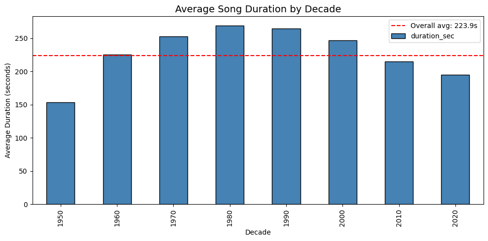

```python
# --- Graph of average song duration by decade ---
fig, ax = plt.subplots(figsize=(10, 5)) # create a plot with 10x5 inch sizing
duration_by_decade.plot(kind='bar', ax=ax, color='steelblue', edgecolor='black') #create a barchart using the duration_by_decade we grouped before
#set axis titles
ax.set_title('Average Song Duration by Decade', fontsize=14)
ax.set_xlabel('Decade')
ax.set_ylabel('Average Duration (seconds)')

#set a horiziontal line showing the average duration across all decades
ax.axhline(y=avg_duration, color='red', linestyle='--', label=f'Overall avg: {avg_duration:.1f}s')
#show legends and display with better spacing so labels dont get cut out
ax.legend()
plt.tight_layout()
plt.show()
```

### What the initial statistics tell us:

1. **There was an average duration of 223.9 seconds or ~3.7 min.** This give us a base line into the standard duration of a song through all genres.
2. **Duration by decade:** We saw that songs grew longer from the 1950s through the 1980s peaking at around 270 seconds but then starting to decline through the 2020s reaching about 196 seconds.
3. **Correlation of -0.14:** There was a slight negative correlation between duration and popularity. Shorter songs tend to be more popular. This would be intresting to explore further.
4. **Popularity by genre:** Pop and Latin lead in popularity while EDM trails.
5. **Duration by genre:** Rock songs average ~247 seconds while Rap averages ~212 seconds. The difference in length per genre could show to be important in our further analysis of what influences the popularity of a song the most.

The bar chart above clearly shows the rise and fall of song length over the decades. In particular, as the data moves into more recent years, we find that the average duration of songs have become much shorter than those released in the past. These statistics prove significant as we look to analyze how the length of a song correlates to its popularity, and how that has impacted how long artists are making their songs now compared to in the past. Additionally, this chart and timeline reflect how this trend may also be related to and influenced by the ever-growing factors of technology and social media platforms like Tik Tok affecting the attention spans of listeners, and how this in turn might impact the length of songs that artists feel will gain the most popularity upon release.

## 5.2 — Billboard-corrected view

Now we will look at the popularity comparison using the Billboard peak position as the popularity metric instead of spotify popularity. To note, the peak position scale is 1-100 where lower numbers are better.

```python
# --- Stat 1: Correlation between duration and Billboard peak position by decade ---
# Add decade column to merged dataset (we created it earlier on spotify only)
merged['decade'] = (merged['release_year'] // 10) * 10

print("Correlation between duration and Billboard peak position by decade:")
print("(Note: peak_position is 1-100 where LOWER = more popular,")
print(" so a positive correlation means longer songs peak worse)\n")
for decade in sorted(merged['decade'].unique()):
    decade_data = merged[merged['decade'] == decade]
    if len(decade_data) < 5:  # skip decades with too few charted songs
        continue
    corr = decade_data['duration_sec'].corr(decade_data['peak_position'])
    print(f"{decade}s (n={len(decade_data)}): {corr:.4f}")
```

```
Correlation between duration and Billboard peak position by decade:
(Note: peak_position is 1-100 where LOWER = more popular,
 so a positive correlation means longer songs peak worse)

1960s (n=38): -0.0065
1970s (n=179): 0.0623
1980s (n=331): -0.0358
1990s (n=491): 0.0913
2000s (n=737): -0.0413
2010s (n=1351): -0.0458
2020s (n=20): -0.1164
```

```python
# --- Stat 2: Cross-tabulation between duration based on decade and genre ---
import pandas as pd
cross_tab = pd.crosstab(
    index=merged['decade'],
    columns=merged['playlist_genre'],
    values=merged['peak_position'],
    aggfunc='mean'
).round(1)
print("\nAverage Billboard Peak Position by Decade and Genre:")
print("(Lower numbers = better chart performance)")
print(cross_tab)
```

```
Average Billboard Peak Position by Decade and Genre:
(Lower numbers = better chart performance)
playlist_genre   edm  latin   pop   r&b   rap  rock
decade
1960             NaN    1.0  14.0  15.7   NaN  20.2
1970             NaN    2.0  11.0  18.9  28.0  21.1
1980            33.0   23.6  16.4  14.3  36.4  17.3
1990             NaN   26.4  24.9  19.4  41.7  25.9
2000            38.7   31.4  19.1  25.0  30.2  32.9
2010            26.7   36.7  28.3  40.9  43.9  34.9
2020            38.7    2.0   NaN  42.0  55.3  75.0
```

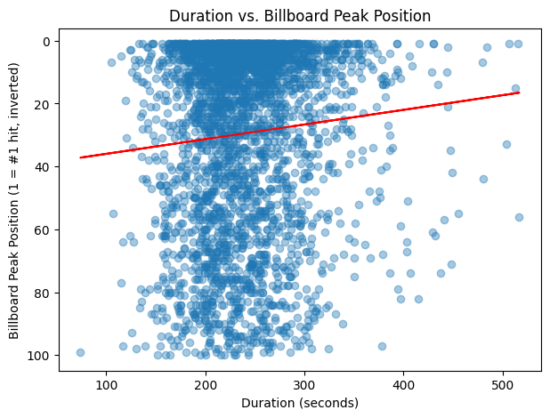

```python
# --- Stat 3: Scatterplot of duration vs Billboard peak position ---
import matplotlib.pyplot as plt
import numpy as np

plt.figure(figsize=(7,5))

plt.scatter(
    # x-axis: song duration in seconds
    merged['duration_sec'],
    # y-axis: best chart position (1 = #1 hit, 100 = barely charted)
    merged['peak_position'],
    alpha=0.4
)

# fit a linear trend line
z = np.polyfit(merged['duration_sec'], merged['peak_position'], 1)
p = np.poly1d(z)
plt.plot(merged['duration_sec'], p(merged['duration_sec']), color='red')

# invert y-axis so "more popular" appears at the top of the plot
plt.gca().invert_yaxis()

# set axis titles
plt.title('Duration vs. Billboard Peak Position')
plt.xlabel('Duration (seconds)')
plt.ylabel('Billboard Peak Position (1 = #1 hit, inverted)')

plt.show()
```

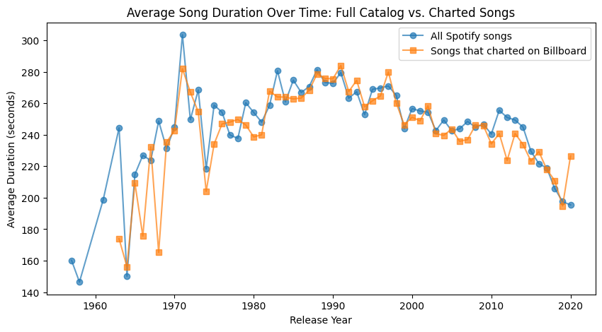

```python
# --- Stat 4: Average duration over time — Spotify catalog vs charted songs ---

spotify_yearly = spotify.groupby('release_year')['duration_sec'].mean()
merged_yearly = merged.groupby('release_year')['duration_sec'].mean()

plt.figure(figsize=(10, 5))
plt.plot(spotify_yearly.index, spotify_yearly.values,
         marker='o', label='All Spotify songs', alpha=0.7)
plt.plot(merged_yearly.index, merged_yearly.values,
         marker='s', label='Songs that charted on Billboard', alpha=0.7)

plt.title('Average Song Duration Over Time: Full Catalog vs. Charted Songs')
plt.xlabel('Release Year')
plt.ylabel('Average Duration (seconds)')
plt.legend()
plt.show()
```

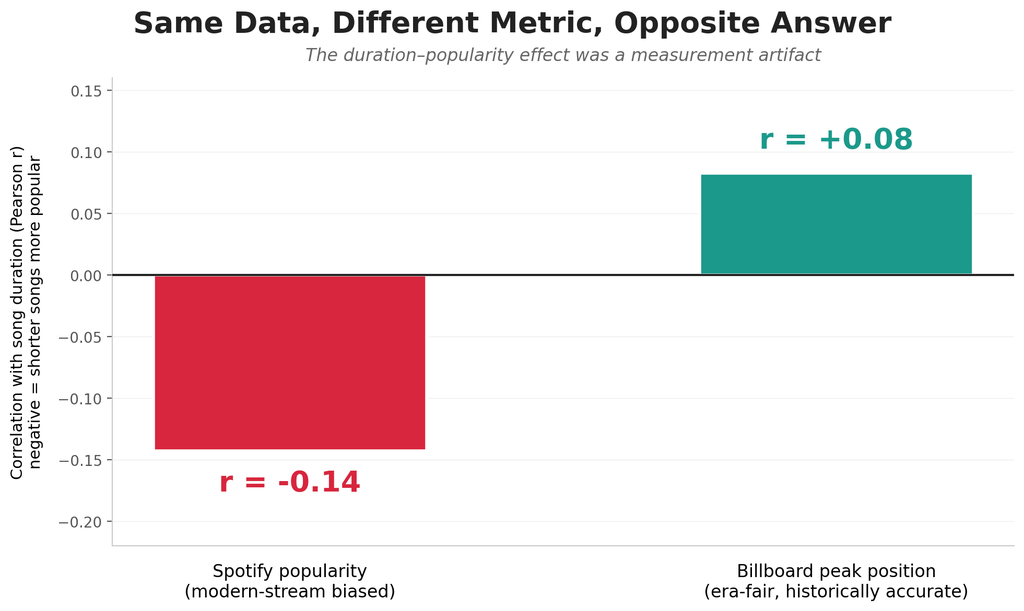

```python
#@title Model 2 visual: two popularity metrics, presentation version

import matplotlib.pyplot as plt

# --- compute correlations ---
spotify_corr = spotify['duration_sec'].corr(spotify['track_popularity'])
billboard_corr = -merged['duration_sec'].corr(merged['peak_position'])

# --- styling ---
plt.rcParams.update({'font.family': 'DejaVu Sans', 'font.size': 13})

fig, ax = plt.subplots(figsize=(10, 6.5), dpi=200)
fig.patch.set_facecolor('white')
ax.set_facecolor('white')

# --- bars ---
labels = ['Spotify popularity\n(modern-stream biased)',
          'Billboard peak position\n(era-fair, historically accurate)']
values = [spotify_corr, billboard_corr]
colors = ['#D7263D', '#1B998B']

bars = ax.bar(labels, values, color=colors, width=0.5,
              edgecolor='white', linewidth=2, zorder=3)

# --- zero baseline ---
ax.axhline(0, color='#222', linewidth=1.5, zorder=4)

# --- bar value labels (placed outside the bars, no overlap with anything) ---
for bar, val in zip(bars, values):
    if val >= 0:
        y_pos = val + 0.015
        va = 'bottom'
    else:
        y_pos = val - 0.015
        va = 'top'
    ax.text(bar.get_x() + bar.get_width() / 2, y_pos,
            f'r = {val:+.2f}',
            ha='center', va=va,
            fontsize=20, fontweight='bold', color=bar.get_facecolor(),
            zorder=5)

# --- y-axis ---
ax.set_ylim(-0.22, 0.16)
ax.set_ylabel('Correlation with song duration (Pearson r)\nnegative = shorter songs more popular',
              fontsize=11, labelpad=10)

# --- x-axis: bigger, bolder labels ---
ax.tick_params(axis='x', length=0, pad=12, labelsize=12)
ax.tick_params(axis='y', labelsize=10, colors='#555')

# --- grid + spines ---
ax.grid(axis='y', linestyle='-', linewidth=0.5, color='#EEE', zorder=0)
ax.set_axisbelow(True)
for spine in ['top', 'right']:
    ax.spines[spine].set_visible(False)
for spine in ['left', 'bottom']:
    ax.spines[spine].set_color('#CCC')

# --- titles ---
fig.suptitle('Same Data, Different Metric, Opposite Answer',
             fontsize=20, fontweight='bold', y=0.97, color='#222')
ax.set_title('The duration–popularity effect was a measurement artifact',
             fontsize=12, color='#666', pad=12, style='italic')

plt.tight_layout()
plt.subplots_adjust(top=0.87, bottom=0.18)
plt.savefig('two_metric_comparison_v3.png', dpi=250, bbox_inches='tight',
            facecolor='white')
plt.show()
```

### What the further merged-dataset analysis tells us:

In the Spotify EDA in which we used track_popularity, it reflected current streaming activity which meant that older songs looked unpopular even if they were big in their respective eras. We added the top 100 billboards dataset to get a better look at how popular the track was in its respective era. Now for the merged EDA, we are using a more historically accurate dataset.

After doing a deeper analysis of the merged dataset, we see that the duration trend over time where after the 2000s it starts to decline is true. But the initial hypothesis that duration affected popularity doesn't hold up when we implement historically accurate "popularity" data (based on the rankings of the billboards). Going even further, we would look into the how and why the music industry is making shorter songs rather than are the shorter songs making them more popular.

# 6. Modeling

We will have use two models for each research question in order to back our findings and prove or disprove our hypothesis.

**Research Question 1 - Has duration changed over time?**

Model 1:

- **Dependent Variable:** yearly mean `duration_sec`
- **Independent Variables:** `release_year`, `post_2000`, and interaction between the two
- **Model Used:** Piecewise OLS regression
- **Why this Model?:** This model allows us to directly test whether the trend in song duration changes after 2000. Because it is a linear and highly interpretable model, it gives a clear statistical test and p-value for whether the slope before 2000 differs from the slope after 2000.

**Research Question 2 - Does duration predict chart success differently by era?**

Model 1:

- **Dependent Variable:** `peak_position`
- **Independent Variables:** `duration_sec`, `post_2000`, and interaction between the two
- **Model Used:** Multiple OLS
- **Why this Model?:** This model directly tests Hypothesis 2 by examining whether the relationship between song duration and chart success changes after 2000. The interaction term allows us to determine whether shorter songs became more successful during the streaming era.

Model 2:

- **Dependent Variable:** `peak_position`
- **Independent Variables:** `duration_sec`, `release_year`, `playlist_genre`
- **Model Used:** Decision tree regressor
- **Why this Model?:** Unlike linear regression, decision trees can automatically detect non-linear relationships and interactions between variables. This provides a more flexible modeling approach. If the decision tree still finds little relationship between duration and chart success, it would support the idea that there is no strong duration effect.

## 6.1 — Research Question 1: Has song duration changed over time?

### Model A — Piecewise OLS Regression

```
                            OLS Regression Results
==============================================================================
Dep. Variable:       avg_duration_sec   R-squared:                       0.508
Model:                            OLS   Adj. R-squared:                  0.482
Method:                 Least Squares   F-statistic:                     19.59
Date:                Wed, 06 May 2026   Prob (F-statistic):           7.52e-09
Time:                        20:04:13   Log-Likelihood:                -272.17
No. Observations:                  61   AIC:                             552.3
Df Residuals:                      57   BIC:                             560.8
Df Model:                           3
Covariance Type:            nonrobust
====================================================================================
                       coef    std err          t      P>|t|      [0.025      0.975]
------------------------------------------------------------------------------------
Intercept          288.2409      6.899     41.783      0.000     274.427     302.055
year_c               1.9667      0.290      6.793      0.000       1.387       2.546
post_2000          -25.9194     11.449     -2.264      0.027     -48.845      -2.994
year_c:post_2000    -4.4172      0.833     -5.300      0.000      -6.086      -2.748
==============================================================================
Omnibus:                       10.939   Durbin-Watson:                   1.316
Prob(Omnibus):                  0.004   Jarque-Bera (JB):               25.012
Skew:                          -0.348   Prob(JB):                     3.70e-06
Kurtosis:                       6.059   Cond. No.                         91.8
==============================================================================

Notes:
[1] Standard Errors assume that the covariance matrix of the errors is correctly specified.

=== Model 1 — Plain-English interpretation ===
Pre-2000 slope:  +1.97 sec/year (95% CI [+1.39, +2.55])
Post-2000 slope: -2.45 sec/year
Slope change at 2000: -4.42 sec/year, p = 1.95e-06
R-squared: 0.508
```

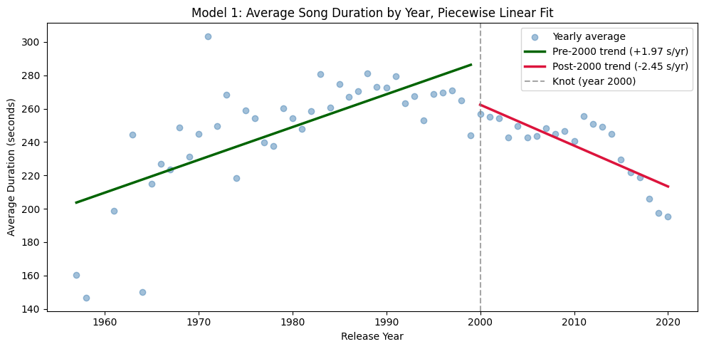

```python
import statsmodels.formula.api as smf

# Aggregate Spotify songs to one observation per year
yearly = (
    spotify.groupby('release_year')['duration_sec']
    .mean()
    .reset_index()
    .rename(columns={'duration_sec': 'avg_duration_sec'})
)

# Build piecewise predictors centered at the cutoff so coefficients are
# directly interpretable at the year-2000 boundary
CUTOFF = 2000
yearly['year_c']    = yearly['release_year'] - CUTOFF
yearly['post_2000'] = (yearly['release_year'] >= CUTOFF).astype(int)

# Fit OLS with an interaction term. The interaction coefficient
# (year_c:post_2000) is exactly "how much the slope changes after 2000",
# and statsmodels gives us its p-value and CI for free.
model1 = smf.ols('avg_duration_sec ~ year_c * post_2000', data=yearly).fit()
print(model1.summary())

# Pull out the key numbers
slope_pre    = model1.params['year_c']
slope_change = model1.params['year_c:post_2000']
slope_post   = slope_pre + slope_change
ci = model1.conf_int()

print("\n=== Model 1 — Plain-English interpretation ===")
print(f"Pre-2000 slope:  {slope_pre:+.2f} sec/year "
      f"(95% CI [{ci.loc['year_c', 0]:+.2f}, {ci.loc['year_c', 1]:+.2f}])")
print(f"Post-2000 slope: {slope_post:+.2f} sec/year")
print(f"Slope change at 2000: {slope_change:+.2f} sec/year, "
      f"p = {model1.pvalues['year_c:post_2000']:.4g}")
print(f"R-squared: {model1.rsquared:.3f}")

# Plot using the model's own predictions
yearly = yearly.sort_values('release_year')
yearly['fitted'] = model1.predict(yearly)

fig, ax = plt.subplots(figsize=(10, 5))
ax.scatter(yearly['release_year'], yearly['avg_duration_sec'],
           alpha=0.5, color='steelblue', label='Yearly average')

pre  = yearly[yearly['release_year'] <  CUTOFF]
post = yearly[yearly['release_year'] >= CUTOFF]
ax.plot(pre['release_year'],  pre['fitted'],  color='darkgreen',
        linewidth=2.5, label=f'Pre-2000 trend ({slope_pre:+.2f} s/yr)')
ax.plot(post['release_year'], post['fitted'], color='crimson',
        linewidth=2.5, label=f'Post-2000 trend ({slope_post:+.2f} s/yr)')
ax.axvline(CUTOFF, color='gray', linestyle='--', alpha=0.7,
           label='Knot (year 2000)')

ax.set_title('Model 1: Average Song Duration by Year, Piecewise Linear Fit')
ax.set_xlabel('Release Year')
ax.set_ylabel('Average Duration (seconds)')
ax.legend()
plt.tight_layout()
plt.show()
```

### Model B — Polynomial Regression

Our first model we assumed that the slope changed at year 2000 by looking at the distributions before. Here we are using degree-3 polynomial model that shows us an curved line throughout the whole dataset to see really where the "peak" and slope change was.

### Model 1 — Interpretation

The piecewise OLS gives us a answer to our first hypothesis. We were able to see the slope change at the 2000 boundary that we can up with confirmed by the p-value.

The polynomial in Model B tells the same story without us having to pick a knot year ahead of time. Both models pointing at the same rise-peak-fall pattern gives us more confidence that the trend over the past 65 years is real and not something we accidentally cooked up by choosing 2000 as the cutoff.

```
Polynomial (degree 3) R-squared: 0.697
Compare to piecewise model R-squared: 0.508
Polynomial-implied peak year(s): [np.float64(1988.2)]
```

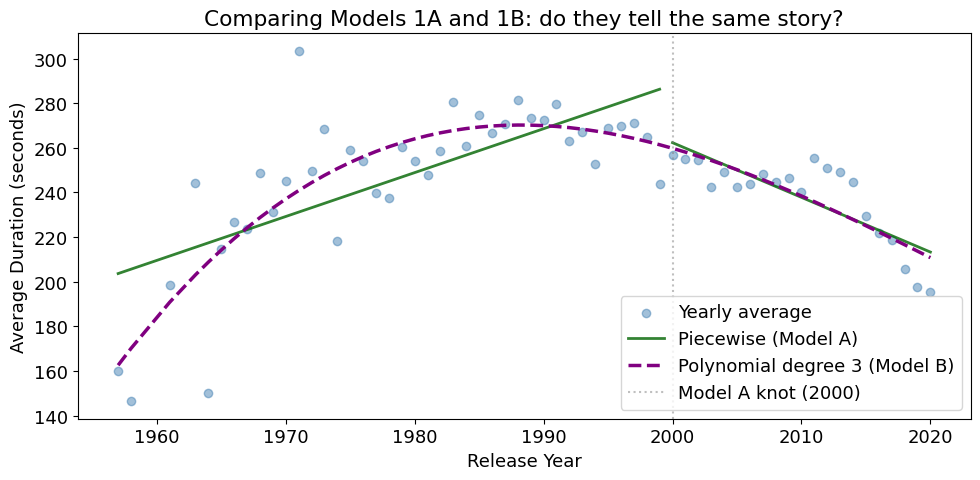

```python
# fit degree 3 polynomial to our yearly average durations using the same data as Model A
poly_coeffs = np.polyfit(yearly['release_year'],
                         yearly['avg_duration_sec'],
                         deg=3)
# make coefficients into a function
poly_fn = np.poly1d(poly_coeffs)
# get predicted duration for each year and make it a column
yearly['poly_fitted'] = poly_fn(yearly['release_year'])

# computer the r square (the miss of the predicted vs the actual value)
ss_res = ((yearly['avg_duration_sec'] - yearly['poly_fitted']) ** 2).sum()
# how much the value varies aorund mean
ss_tot = ((yearly['avg_duration_sec'] - yearly['avg_duration_sec'].mean()) ** 2).sum()
poly_r2 = 1 - ss_res / ss_tot

# print polynomial r square vs piecewise one
print(f"Polynomial (degree 3) R-squared: {poly_r2:.3f}")
print(f"Compare to piecewise model R-squared: {model1.rsquared:.3f}")

# find where the curve derivative equals zero becuase that is the crossing point
deriv = poly_fn.deriv()

# gives us the years where slope is zero
roots = deriv.roots

# has to be within our release year dataset range
real_peaks = [r.real for r in roots
              if abs(r.imag) < 1e-6
              and yearly['release_year'].min() < r.real < yearly['release_year'].max()]
if real_peaks:
    print(f"Polynomial-implied peak year(s): "
          f"{[round(p, 1) for p in real_peaks]}")

# plot both so we can see the difference
fig, ax = plt.subplots(figsize=(10, 5))
ax.scatter(yearly['release_year'], yearly['avg_duration_sec'],
           alpha=0.5, color='steelblue', label='Yearly average')

# fit the piecewise with the 2000 cutoff
pre  = yearly[yearly['release_year'] <  CUTOFF]
post = yearly[yearly['release_year'] >= CUTOFF]
ax.plot(pre['release_year'], pre['fitted'], color='darkgreen',
        linewidth=2, label='Piecewise (Model A)', alpha=0.8)
ax.plot(post['release_year'], post['fitted'], color='darkgreen',
        linewidth=2, alpha=0.8)

#  sort by year before plotting
yearly_sorted = yearly.sort_values('release_year')
# draw polynomial curve on the chart
ax.plot(yearly_sorted['release_year'], yearly_sorted['poly_fitted'],
        color='purple', linewidth=2.5, linestyle='--',
        label='Polynomial degree 3 (Model B)')

ax.axvline(CUTOFF, color='gray', linestyle=':', alpha=0.5,
           label='Model A knot (2000)')

# set title, labels and legend.
ax.set_title('Comparing Models 1A and 1B: do they tell the same story?')
ax.set_xlabel('Release Year')
ax.set_ylabel('Average Duration (seconds)')
ax.legend()
plt.tight_layout()
plt.show()
```

**Model 1A vs 1B — Similar Findings**

## 6.2 — Research Question 2: Does duration predict chart success?

### Model A — Multiple OLS with Era × Duration Interaction

```
Modeling on 3147 songs (2108 post-2000, 1039 pre-2000)
                            OLS Regression Results
==============================================================================
Dep. Variable:          peak_position   R-squared:                       0.037
Model:                            OLS   Adj. R-squared:                  0.036
Method:                 Least Squares   F-statistic:                     40.42
Date:                Wed, 06 May 2026   Prob (F-statistic):           1.27e-25
Time:                        20:04:44   Log-Likelihood:                -15030.
No. Observations:                3147   AIC:                         3.007e+04
Df Residuals:                    3143   BIC:                         3.009e+04
Df Model:                           3
Covariance Type:            nonrobust
========================================================================================
                           coef    std err          t      P>|t|      [0.025      0.975]
----------------------------------------------------------------------------------------
Intercept               21.4843      0.954     22.512      0.000      19.613      23.356
duration_c               0.0216      0.016      1.377      0.169      -0.009       0.052
post_2000               11.2059      1.151      9.738      0.000       8.950      13.462
duration_c:post_2000    -0.0702      0.021     -3.364      0.001      -0.111      -0.029
==============================================================================
Omnibus:                      352.152   Durbin-Watson:                   1.906
Prob(Omnibus):                  0.000   Jarque-Bera (JB):              383.986
Skew:                           0.808   Prob(JB):                     4.15e-84
Kurtosis:                       2.436   Cond. No.                         169.
==============================================================================

Notes:
[1] Standard Errors assume that the covariance matrix of the errors is correctly specified.

=== Model 2 — Plain-English interpretation ===
Reminder: peak_position 1-100 where LOWER = more popular.
So a POSITIVE duration coefficient means longer songs peak WORSE.

Pre-2000:  each extra 60s shifts peak by +1.29 positions
Post-2000: each extra 60s shifts peak by -2.92 positions
Difference between eras: -4.21 per 60s, p = 0.000777
R-squared: 0.0371  (adj: 0.0362)
```

[figure not shown]

```python
# Center duration so the post_2000 main effect is interpretable as the
# era shift "for a typical-length song" rather than for a 0-second song
mean_dur = merged['duration_sec'].mean()
merged['duration_c'] = merged['duration_sec'] - mean_dur
merged['post_2000']  = (merged['release_year'] >= 2000).astype(int)

# Drop any rows with missing modeling values
model_data = merged.dropna(
    subset=['peak_position', 'duration_c', 'post_2000']
).copy()

print(f"Modeling on {len(model_data)} songs "
      f"({int(model_data['post_2000'].sum())} post-2000, "
      f"{int((1 - model_data['post_2000']).sum())} pre-2000)")

# Fit the FULL interaction model that our markdown described
model2 = smf.ols('peak_position ~ duration_c * post_2000',
                 data=model_data).fit()
print(model2.summary())

# Pull the key numbers
b_dur_pre    = model2.params['duration_c']
b_dur_change = model2.params['duration_c:post_2000']
b_dur_post   = b_dur_pre + b_dur_change
p_dur_change = model2.pvalues['duration_c:post_2000']

print("\n=== Model 2 — Plain-English interpretation ===")
print("Reminder: peak_position 1-100 where LOWER = more popular.")
print("So a POSITIVE duration coefficient means longer songs peak WORSE.\n")
print(f"Pre-2000:  each extra 60s shifts peak by {b_dur_pre*60:+.2f} positions")
print(f"Post-2000: each extra 60s shifts peak by {b_dur_post*60:+.2f} positions")
print(f"Difference between eras: {b_dur_change*60:+.2f} per 60s, p = {p_dur_change:.3g}")
print(f"R-squared: {model2.rsquared:.4f}  (adj: {model2.rsquared_adj:.4f})")

# Plot predicted lines for each era over a scatter of the actual data
import numpy as np
fig, ax = plt.subplots(figsize=(10, 6))

for label, sub, color in [
    ('Pre-2000 songs',  model_data[model_data['post_2000'] == 0], 'steelblue'),
    ('Post-2000 songs', model_data[model_data['post_2000'] == 1], 'crimson'),
]:
    ax.scatter(sub['duration_sec'], sub['peak_position'],
               alpha=0.12, s=8, color=color, label=label)

# Model prediction lines
xs = np.linspace(model_data['duration_sec'].quantile(0.02),
                 model_data['duration_sec'].quantile(0.98), 100)
for era, color, lbl in [(0, 'navy', 'Pre-2000 fit'),
                         (1, 'darkred', 'Post-2000 fit')]:
    pred_df = pd.DataFrame({'duration_c': xs - mean_dur, 'post_2000': era})
    ax.plot(xs, model2.predict(pred_df), color=color, linewidth=3, label=lbl)

ax.invert_yaxis()
ax.set_xlabel('Song duration (seconds)')
ax.set_ylabel('Billboard peak position (1 = #1 hit)')
ax.set_title('Model 2: Duration vs. Chart Peak, Album Era vs. Streaming Era')
ax.legend(loc='lower right')
plt.tight_layout()
plt.show()
```

### Model B — Decision Tree Regressor (non-linear cross-check)

In order to maybe find non linear effects we will use a decision tree to see if there are features we are not considering that does have an effect on popularity.

```
Decision tree R-squared (test set): 0.0534
Mean absolute error (test set):     23.69 chart positions

For reference, predicting the mean peak position for every song
would give MAE ≈ 25.10
```

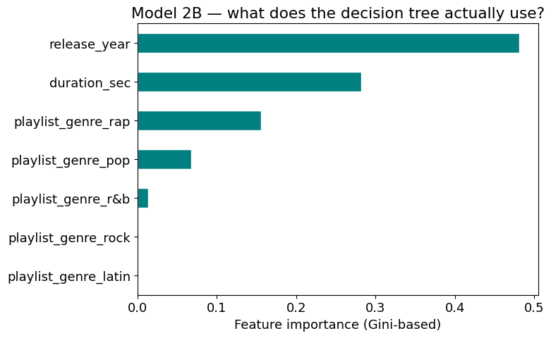

```
Feature importances:
release_year            0.4810
duration_sec            0.2824
playlist_genre_rap      0.1560
playlist_genre_pop      0.0674
playlist_genre_r&b      0.0132
playlist_genre_rock     0.0000
playlist_genre_latin    0.0000
dtype: float64
```

```python
# we use train split to train and evaluate
from sklearn.tree import DecisionTreeRegressor
from sklearn.model_selection import train_test_split
from sklearn.metrics import r2_score, mean_absolute_error

# drop rows with missing values
tree_data = merged.dropna(
    subset=['peak_position', 'duration_sec', 'release_year', 'playlist_genre']
).copy()

# one hot encode genres because we cannot use text columns
X = pd.get_dummies(
    tree_data[['duration_sec', 'release_year', 'playlist_genre']],
    columns=['playlist_genre'],
    drop_first=True
)
# target variable (trying to predict peak position)
y = tree_data['peak_position']

# split training and test sets 80/20
X_train, X_test, y_train, y_test = train_test_split(
    X, y, test_size=0.2, random_state=42
)

# max_depth of 5 so we dont keep splitting to overfits
tree = DecisionTreeRegressor(max_depth=5, random_state=42)

# fit tree on training data
tree.fit(X_train, y_train)

# trained tree to predict peak position
y_pred = tree.predict(X_test)

# r squared to see how much variation is understood by the model
test_r2 = r2_score(y_test, y_pred)
# mae to tell us average error
test_mae = mean_absolute_error(y_test, y_pred)

#print test scores
print(f"Decision tree R-squared (test set): {test_r2:.4f}")
print(f"Mean absolute error (test set):     {test_mae:.2f} chart positions")
print(f"\nFor reference, predicting the mean peak position for every song")
print(f"would give MAE ≈ {(y_test - y_test.mean()).abs().mean():.2f}")

# feature importance to see what features were used more to make splits
importances = pd.Series(tree.feature_importances_, index=X.columns)
importances = importances.sort_values(ascending=True)

# plot it in a bar chart and set title and labels
fig, ax = plt.subplots(figsize=(8, 5))
importances.plot(kind='barh', ax=ax, color='teal', edgecolor='white')
ax.set_xlabel('Feature importance (Gini-based)')
ax.set_title('Model 2B — what does the decision tree actually use?')
plt.tight_layout()
plt.show()

print("\nFeature importances:")
print(importances.sort_values(ascending=False).round(4))
```

These two models both gave us the same output and reasoning in that the popularity of songs are driven by factors that were not present in our dataset. Both models were needed to properly test the hypothesis in which we thought the duration and other features would be able to predict the popularity.

# Conclusion

**1. Song duration has changed.** Model 1's piecewise regression shows durations grew at roughly +2 seconds per year before 2000 and have shrunk at roughly −2 seconds per year since. The change in slope at 2000 is highly statistically significant (p < 0.001) — this isn't year-to-year noise, it's a real structural break.

**3. Together, these point to a supply-side explanation.** If audiences don't reward shorter songs on the charts but artists keep making them shorter anyway, the cause is likely the streaming compensation model — Spotify pays per stream after 30 seconds, so packing more songs into an album increases revenue regardless of listener preference.

**The most important methodological takeaway** is the gap between our two EDAs. With Spotify's recency-biased popularity score, we got r = −0.14 — modest evidence for "shorter songs are more popular." With Billboard's era-fair peak position, the correlation evaporated. **The metric you measure shapes the answer you get** — a single-source finding should always be checked against an independent measure when one exists.

## Further Resources

```python
%%shell
jupyter nbconvert --to html "/content/drive/My Drive/Colab Notebooks/data_science_milestone_2.ipynb"
```

[output not shown]

[output cut: 136 more lines]

[output not shown]

[output not shown]